# Lab1 - Estimators

BETTAIEB Ghassen

09/10/2020

Deadline 20/10

# Rayleigh Distribution

## Theory

The Rayleigh distribution is defined with the following density function :
$$f_a(x) = \frac{x}{a} e^{-\frac{x^2}{2a}}$$

It is used in a wide variety of problems, in particular it can be use to model the yearly maximum height of a river. In that scenario, we would like to predict the probability of the river to reach over 6m high which would leads to flooding of the neighboring area.

For that, we will need to estimate the parameters of our model and then study the estimators.

### Estimators

#### Maximum likelihood estimator

First, we will derive an estimator with the maximum likelihood method.The likelihood of the Rayleigh distribution is as follows :
$$\mathcal{L}(x | a) = \prod_{i=1}^{n} \frac{x_i}{a} e^{-\frac{x_i^2}{2a}}$$
It is clear that to maximise this function, it is easier to consider $L = log(\mathcal L)$ :
$$l(x|a) = \sum_{i=1}^{n} log(x_i) - log(a) - \frac{x_i^2}{2a}$$
$$\frac{∂}{∂a} l(x|a) = -\frac{n}{a} + \frac{1}{2a^2} · \sum_{i=1}^{n}x_i^2$$
The extremums verify the following:
$$\frac{∂}{∂a} l(x|â_n) = 0\ \ \Longleftrightarrow\ \ \boxed{â_n = \frac{1}{2n} · \sum_{i=1}^{n}x_i^2}\ \ \ \ \ \ (a>0)$$
$$\frac{∂^2}{∂a^2} l(x|â_n) = \frac{n}{â_n^2} - \frac{1}{â_n^3} · \sum_{i=1}^{n}x_i^2 = - \frac{4n^3}{\sum_{i=1}^{n}x_i^2} < 0$$
$\therefore$ $â_n$ is the maximum of $l$, so $â_n$ is also the maximum of $\mathcal{L}$.

$â_n$ is the maximum likelihood estimator of $a$.

#### Method of Moment estimator

Another way to derive an estimator of $a$ is via the method of moment. As we only need to estimate one variable, we will only consider the first moment.
$$E(X) = \int_0^{+\infty} \frac{x^2}{a} e^{-\frac{x^2}{2a}} dx = \sqrt{\frac{\pi a}{2}}$$
$\overline{a}_n$, the method of moment estimator is defined as follows:
$$\frac 1 n · \sum_{i=1}^{n}x_i = \sqrt{\frac{\pi \overline{a}_n}{2}}$$
$$\boxed{\overline{a}_n = \frac{2}{\pi n^2} · \left(\sum_{i=1}^{n}x_i\right)^2}$$

### Property of the estimators

#### Bias

$$E(â_n) = \frac{1}{2n} · \sum_{i=1}^{n}E(X_i^2) = \frac{1}{2} · \int_{0}^{+\infty} \frac{x^3}{a}·e^{-\frac{x^2}{2a}} = a$$
$â_n$ is unbiased.

#### Optimal

$â_n$ is not optimal if we consider all the estimators; but it is optimal in the class of unbiased estimators because it is efficient.
$$\tilde{a}_n = \frac{a^2}{1+n}\text{ is an estimator with a smaller MSE than }â_n$$
#### Efficient Let us consider $s_a(x) = \frac{∂}{∂a}log(\mathcal{L}(x;a))$ the score function of the distribution. The Fisher Information for a n samples vector is defined as follows :
$$I_n(a) = E\left(s_a(x)·s_a(x)^T\right) = E\left(\left(-\frac{n}{a} + \frac{1}{2a^2}·\sum_{i=1}^{n}x_i^2\right)^2\right) = \frac{n}{a^2}$$
Then the Cramer Rao Bound of the distribution is
$$CRB(a) = \frac{1}{I_n(a)} \boxed{= \frac{a^2}{n}}$$
The variance of our estimator is the following :
$$Var(â_n) = E\left(\left(\frac{\sum_{i=1}^{n} x_i^2}{2n}\right)^2\right) - E\left(\frac{\sum_{i=1}^{n} x_i^2}{2n}\right)^2 = \frac{a^2}{n}$$
$\therefore Var(â_n) = CRB(a)$, and $â_n$ is efficient, and so is optimal. #### Asymptotically gaussian $â_n$ is asymptotically gaussian because it is an estimator derived by the minimun likelihood method and the model is identifiable and $â_n$ is regular.

### Pré-application

The probability $p$ is the probability that the height of the river exceed 6 meters.
$$p = \int_6^{+\infty} \frac{x}{a} e^{-\frac{x^2}{2a}} dx = exp\left(-\frac{18}{a}\right)$$
The probability that at most one disaster occur during one thousand year is the following :
$$p_{1000} = (1-p)^{999} · (1-p+1000p) = \left(1-exp\left(-\frac{18}{a} \right)\right)^{999}·\left(1+999·exp\left(-\frac{18}{a} \right)\right)$$

With the following observations :
$$x = (2,5\ \ \ 1,8\ \ \ 2,9\ \ \ 0,9\ \ \ 2,1\ \ \ 1,7\ \ \ 2,2\ \ \ 2,8)$$

$$â_8 = \frac{1}{16} · x·x^T ≈ 2.418125$$

We get the following probability of having at most one disaster occuring during one thousand year.
$$\hat{p}_{1000} = \left(1-exp\left(-\frac{18}{â} \right)\right)^{999}·\left(1+999·exp\left(-\frac{18}{â} \right)\right) ≈ 0.8830305$$

## Application

```r
  library(ggplot2)
```

### Generation of the distribution

#### Inversion of the CDF

To generate the Rayleigh distribution, we will use the inversion of the CDF technique. Lets define:
$$F^-(u) = inf\{x, F(x)⩾u\}\ \ \ \text{where F is the CDF of the Rayleigh distribution}$$
$$F^-(u) = inf\left\{x, 1-exp\left(-\frac{x^2}{2a} \right) ⩾ u\right\}$$
$$F^-(u) = \sqrt{-2a·log\left(1-u \right)}\ \ \ \text{well defined on u}\in[0,1[$$

$\therefore$ If $U \sim \mathcal{U}_{[0,1]}$, $F^-(U) \sim \mathcal{R}_{ay}(a)$. We can also simplify $1-U$ in $U$ because they both follow the same distribution.

```r
U = runif(1000)
X = sqrt(-2 * a * log(U))
d = as.data.frame(X, col.names="x")
ggplot(data=d, aes(x=X, y=..density..)) + geom_histogram(binwidth=.3)
```

[output not shown]

#### Composition of multiple random variables

Another way to generate the Rayleigh distribution would be to use the following fact : if $X\sim \mathcal{N}(0,a)$ and $Y\sim \mathcal{N}(0,a)$, then $Z = \sqrt{X^2 + Y^2} \sim \mathcal{R}_{ay}(a)$, because :
$$f_Z(z) = \int_{-z}^z \frac{z}{\sqrt{z^2-x^2}} · \left(f_{XY}\left(x, \sqrt{z^2-x^2}\right) + f_{XY}\left(x, -\sqrt{z^2-x^2}\right) \right)$$
$$f_Z(z) = \frac{z}{a}· exp\left(-\frac{z^2}{2a}\right)$$

```r
X = rnorm(1000, sd=sqrt(a))
Y = rnorm(1000, sd=sqrt(a))
Z = sqrt(X*X + Y*Y)
d = as.data.frame(Z, col.names="z")
ggplot(data=d, aes(x=Z, y=..density..)) + geom_histogram(binwidth=.3)
```

[output not shown]

### Verification of the different properties

#### Unbiasedness

```r
# Eval E(â-a)
Na = 10
Nv = 5
A = matrix(0, nrow=Na, ncol=Nv)
for (a in 1:Na)
{
  for (i in 1:Nv)
  {
    U = runif(10^i)
    X = sqrt(-2 * a * log(U))
    ahat = 1/(2*10^i)*sum(X*X)
    A[a,i] = ahat - a
  }
}
d = as.data.frame(t(A), col.names=1:10)
matplot(rownames(d),d,type='l')
```

[output not shown]

```r
Na = 10
Nv = 5
A = matrix(0, nrow=Na, ncol=Nv)
for (a in 1:Na)
{
  for (i in 1:Nv)
  {
    U = runif(10^i)
    X = sqrt(-2 * a * log(U))
    ahat = 1/(2*10^i)*sum(X*X)
    A[a,i] = ahat - a
  }
}
d = as.data.frame(t(A), col.names=1:10)
matplot(rownames(d),d,type='l')
```

[output not shown]

### Asymptotic Normality

```r
a = 5
N = 10000
Nv = 10000
vals = c(1:Nv)
for (i in 1:Nv)
{
  U = runif(N)
  X = sqrt(-2 * a * log(U))
  ahat = 1/(2*N)*sum(X*X)
  vals[i] = sqrt(N)*(ahat - a)
}
d = as.data.frame(vals, col.names="x")
ggplot(data=d, aes(x=vals, y=..density..)) + geom_histogram(binwidth=1.)
```

[output not shown]

# Geometric Distribution

## Theory

The geometric distribution is defined by the following PMF
$$P(X=k)=(1−q)^{k−1}.q , k∈N^{*}$$

### Estimators

#### Maximum likelihood estimator

First, we will derive an estimator with the maximum likelihood method.The likelihood of the Rayleigh distribution is as follows :
$$\mathcal{L}(x | q) = \prod_{i=1}^{n} (1−q)^{i−1}q = q^{n}e^{ln(1-q)\sum_{i=1}^{n} x_{i}}$$

From the previous formula it’s clear that this PMF belongs to the exponential family. It is also clear that a sufficient statistic is:
$$S = \sum_{i=1}^{n} X_{i}$$

Let $x_1,...,x_n$ a sample with same distribution as $x$. it is easier to consider $L = log(\mathcal L)$

$$l(x|q) = n.log(q) + log(1-q).\sum_{i=1}^{n} (x_i-1)$$
$$\frac{∂}{∂q} l(x|q) = \frac{n}{q} - \frac{1}{1-q} · \sum_{i=1}^{n}(x_i - 1)$$
The extremes verify the following:
$$\frac{∂}{∂q} l(x|\hat q_n)) = 0\ \ \Longleftrightarrow\ \ \boxed{\hat q_n = n· \frac{1}{\sum_{i=1}^{n}x_i} = \frac{1}{\overline X_n}}\ \ \ \ \ \$$
$$\frac{∂^2}{∂q^2} l(x|\hat q_n) = -\frac{n}{\hat q^2} - (\frac{1}{1-\hat q})^2· \sum_{i=1}^{n}(x_i - 1) = -\frac{n}{\hat q^2.(1-\hat q)} <0$$

Therefore $\hat q_n$ is the maximum of $l$, so $\hat q_n$ is also the maximum of $\mathcal{L}$.

$\hat q_n$ is the maximum likelihood estimator of $q$.

Let us compute the Fisher Information for parameter $q$ (We can use only 1 r.V since our variables are iid)

#### Fischer Information

$$\begin{align*}
I(q) &= E_q[-\frac{∂^2}{∂q^2} l_i(x_i|q)] \\
&= E_q[-\frac{1}{q^2} - (\frac{1}{1-q})^2·(x_i - 1) ] \\
&= \frac{1}{q^2} + (\frac{1}{1-q})^2.(E[x_i] - 1) \\
&= \frac{1}{q^2.(1-q)}
\end{align*}$$
#### Estimator Asymptotically gaussian

Let’s prove that the maximum likelihood estimator is asymptotically Gaussian

Since $X_1, X_2, ..,X_n$ are $i.i.d$ with $E[X] = \frac {1}{q_0}$ and $Var[X] = \frac {(1-q_0)}{q_0^2}$, We use the CLT Theorem to get:
$$\sqrt{n} (\overline X_n - \frac {1}{q_0}) \xrightarrow[]{d} \mathcal{N}(0, \frac{1-q_0}{q_0^2})$$
where $q_0$ is the true value of the parameter $q$ Let us consider a function $g$, $g(z) = 1/z$. $g$ is a continuous and continuously differentiable function with $g(1/q) = q\neq 0$, then we can apply the delta method :

$$\sqrt{n} (g(\overline X_n) - g(\frac {1}{q_0})) \xrightarrow[]{d} \mathcal{N}(0, (\frac{∂g(z)}{∂z}|_{1/q})^2 . \frac{1-q_0}{q_0^2})$$
Finally after simple calculations we get:
$$\sqrt{n} (\hat q - q_0) \xrightarrow[]{d} \mathcal{N}(0, (1-q_0).q_0^2) \\
\implies \hat q \sim \mathcal{N}(q_0, \frac {(1-q_0).q_0^2}{n})$$
So The estimator is asymptotically Gaussian, with an asymptotic variance equal to $\frac {(1-q_0).q_0^2}{n}$. We could have gotten these results using the fact that the log-likelihood satisfies the regularity conditions hence the estimator is asymptotically Gaussian with
$$\sqrt{n} (\hat q - q_0) \xrightarrow[]{d} \mathcal{N}(0, I^{-1}(q_0))$$
where $I^{-1}(q_0)$ is the Fischer Information at $q_0$.

### Asymptotic Confidence interval for q

Let’s calculate a $(1-\alpha)$-confidence interval for $q$. We proved that:
$$\sqrt{n} (\overline X_n - \frac {1}{q_0}) \xrightarrow[]{d} \mathcal{N}(0, \frac{1-q_0}{q_0^2})$$
Hence,
$$\frac {(\overline X_n - \frac {1}{q_0})}{\sqrt{ \frac{1-q_0)}{n.q_0^2}}} \sim \mathcal{N}(0,1)$$
Let $z$ be the critical value of the standard normal distribution for a 0.95 confidence level. So:

$$\frac {(\overline X_n - \frac {1}{q_0})}{\sqrt{ \frac{1-q_0}{n.q_0^2}}}\in\ [-z,z]$$
So the confidence interval, is the interval values of $q_0$ that satisfies the previous condition.

We solve the equation

$$\frac {(\overline X_n - \frac {1}{q_0})}{\sqrt{ \frac{1-q_0}{n.q_0^2}}} = z \\
\iff n.\overline X_n.q_0^2 + (z^2 - 2.n.\overline X_n) + n-z^2 = 0$$
By solving this equation in R (see below) we get two solutions for $q_0$ which constitute the value bounds of the confidence interval.

## Application

### Estimate the fraud probability

```r
cat("fraud probability estimation : ",prob)
```

```
fraud probability estimation :  0.02607562
```

### Verify with a plot the property “asymptotic normality” for the estimator

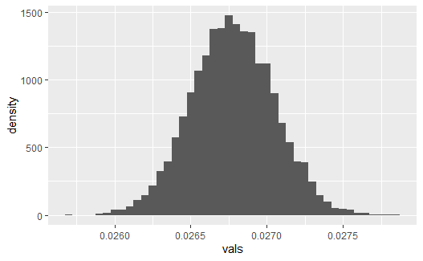

### Compute the confidence interval

```r
cat("Confidence Interval : [",c[2]," , ",c[1],"]")
```

```
Confidence Interval : [ 0.01806818  ,  0.03401775 ]
```

#### Validate the confidence interval with simulations

```r
cat("ratio of simulated values of q outside the confidence interval ",ratio ,"%")
```

```
ratio of simulated values of q outside the confidence interval  0 %
```